# Aplicações de Estatística Espacial

28 de novembro de 2018

## Descrição das atividades

### Trabalho 2

– Faça uma análise descritiva/exploratória (apresentação do espaço, do fenômeno de interesse, além de investigar os efeitos de 1a e 2a ordem) das localizações das ocorrências dos crimes (para toda a base e somente para o crime rape). Ao realizar a análise discutam a estimação da função de intensidade e a existência do efeito de segunda ordem. Ajuste o melhor modelo dentro de cada cenário (geral e só o rape) e interprete os resultados.

## Desenvolvimento

### Plotando a região de interesse

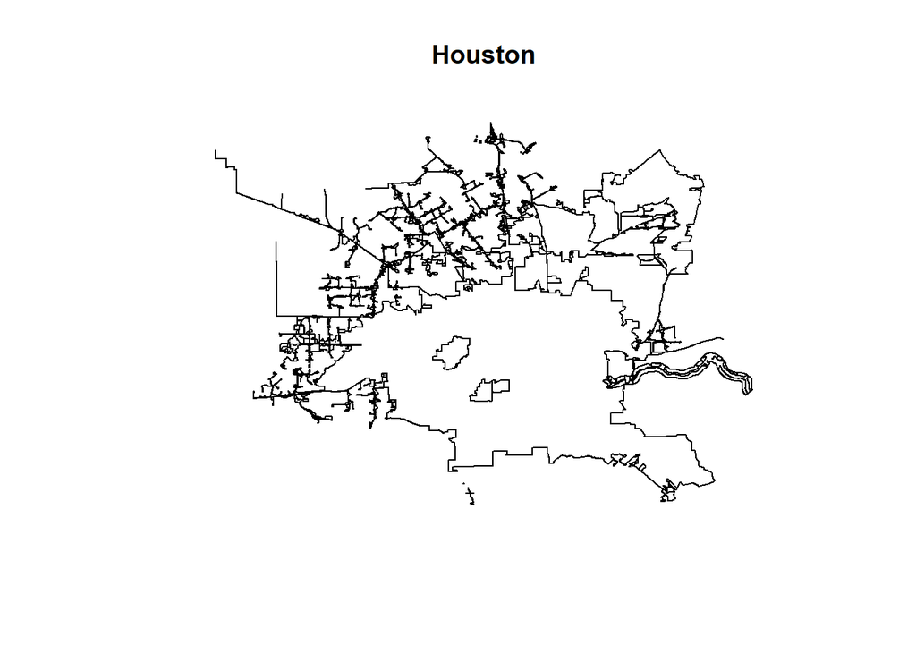

```r
#Definindo o shapefile como uma janela onde os pontos serao plotados
#necessario para o uso do pacote spatstat
Houston <- as.owin(Mapa_Houston)

#Plotando o shapefile
plot(Houston)
```

### Plotando a ocorrencia de crimes na áre a de interesse

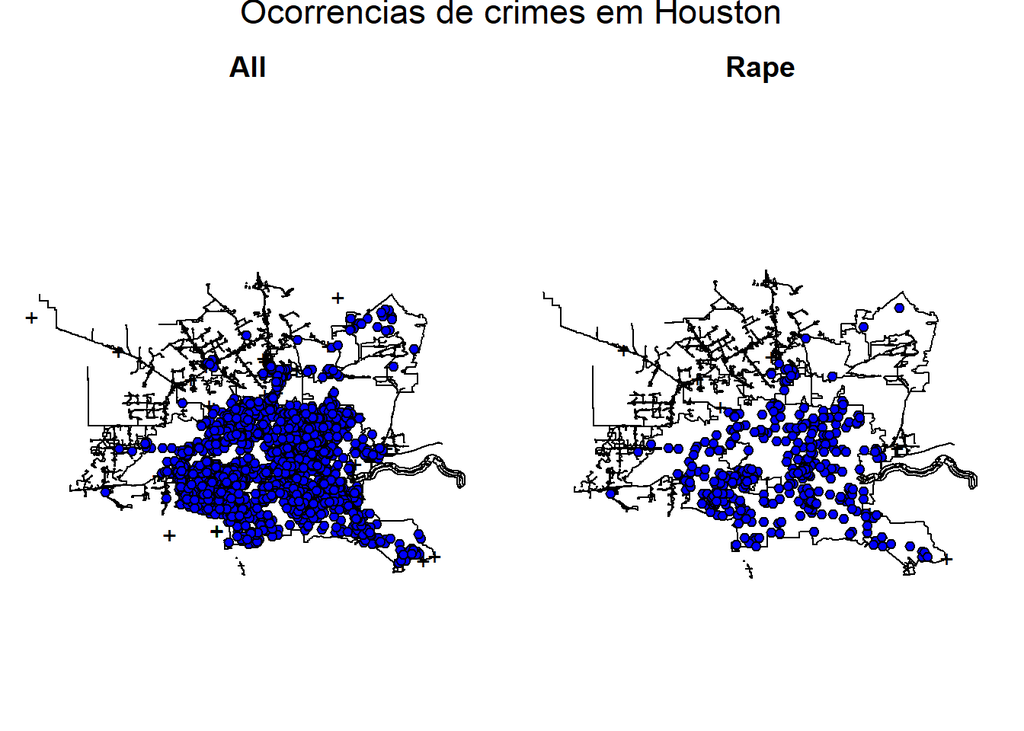

```r
#Criando o padrao de pontos a ser plotado
Houston_ppp = ppp(Base_Houston$lon, Base_Houston$lat, window=Houston)
Houston_Rape_ppp = ppp(Base_Houston_Rape$lon, Base_Houston_Rape$lat, window=Houston)

par(mfrow=c(1,2))
par(mar=c(0.5,0.5,4.5,1))
#Plotando as localizacoes dos delitos
plot(Houston_ppp, pch=21, cex=0.9, bg="blue", main="All")
plot(Houston_Rape_ppp, pch=21, cex=0.9, bg="blue", main="Rape")
mtext("Ocorrencias de crimes em Houston", outer=TRUE ,side = 3,line=-1, cex = 1.4)
```

```r
par(mfrow=c(1,1))
```

Ao analizar a imagem acima, observamos a localidade de cada ocorrencia plotada no mapa. Para identificar se exite algum padrão iremos investigar os efeitos de primeira ordem (escala global) e segunda ordem (escala local).

#### Estimando o efeito de primeira ordem (intensidade) usando diferentes kernels (Quartico, Normal e Epanechnikov)

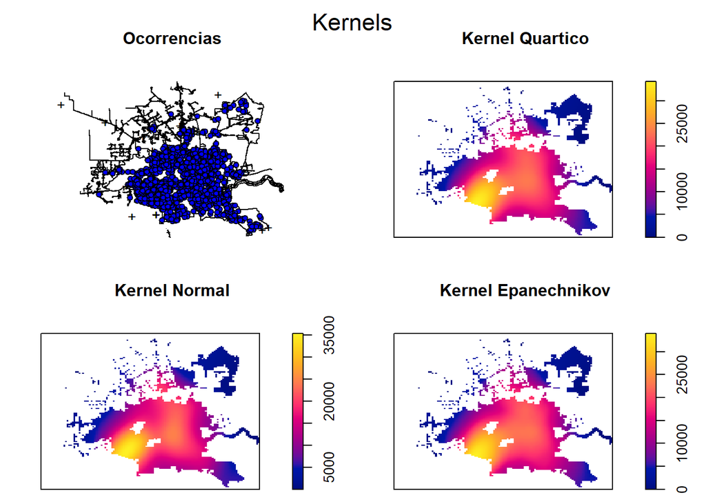

```r
#Estimando o efeito de primeira ordem (intensidade) usando diferentes kernels
Houston.q = density.ppp(x = Houston_ppp, sigma=0.05, kernel="quartic")
Houston.g = density.ppp(x = Houston_ppp, sigma=0.05, kernel="gaussian")
Houston.e = density.ppp(x = Houston_ppp, sigma=0.05, kernel="epanechnikov")

##density.ppp - calcula a funcao de intensidade de acordo com o kernel escolhido
#Argumentos:
#x - objeto da classe ppp
#sigma - é o valor do raio (tau na expressao dos slides)
#kernel - o kernel que deseja-se usar

#-------------------------APRESENTAÇÃO DO ESPAÇO------------------------------------

#Plotando os dados e as funcoes intensidades estimadas pelas diversas funcoes kernel
par(mfrow=c(2,2))
par(mar=c(0.5,0.5,4.5,1))
plot(Houston_ppp, pch=21, cex=0.9, bg="blue", main="Ocorrencias", cex.main=0.5)
plot(Houston.q, main="Kernel Quartico", cex.main=0.5)
plot(Houston.g, main="Kernel Normal")
plot(Houston.e, main="Kernel Epanechnikov")
mtext("Kernels", outer=TRUE ,side = 3,line=-2, cex = 1.4)
```

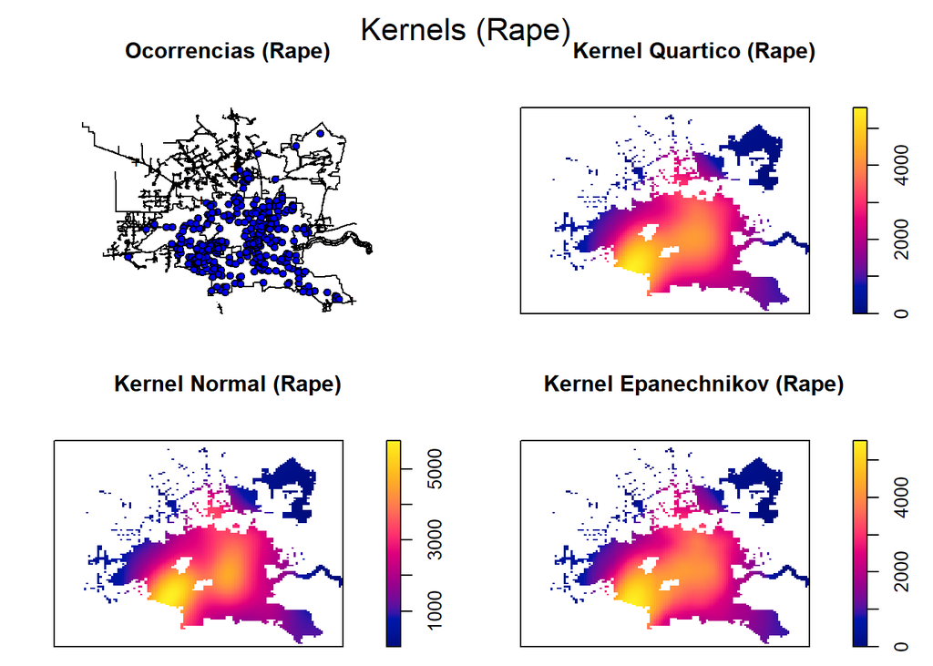

```r
#Estimando o efeito de primeira ordem (intensidade) usando diferentes kernels
Houston_Rape.q = density.ppp(x = Houston_Rape_ppp, sigma=0.05, kernel="quartic")
Houston_Rape.g = density.ppp(x = Houston_Rape_ppp, sigma=0.05, kernel="gaussian")
Houston_Rape.e = density.ppp(x = Houston_Rape_ppp, sigma=0.05, kernel="epanechnikov")

##density.ppp - calcula a funcao de intensidade de acordo com o kernel escolhido
#Argumentos:
#x - objeto da classe ppp
#sigma - é o valor do raio (tau na expressao dos slides)
#kernel - o kernel que deseja-se usar

#-------------------------APRESENTAÇÃO DO ESPAÇO------------------------------------

par(mfrow=c(2,2))
par(mar=c(0.5,0.5,4.5,1))
plot(Houston_Rape_ppp, pch=21, cex=0.9, bg="blue", main="Ocorrencias (Rape)", cex.main=0.5)
plot(Houston_Rape.q, main="Kernel Quartico (Rape)", cex.main=0.5)
plot(Houston_Rape.g, main="Kernel Normal (Rape)")
plot(Houston_Rape.e, main="Kernel Epanechnikov (Rape)")
mtext("Kernels (Rape)", outer=TRUE ,side = 3,line=-2, cex = 1.4)
```

```r
par(mfrow=c(1,1))
```

##### Estimando o Raio

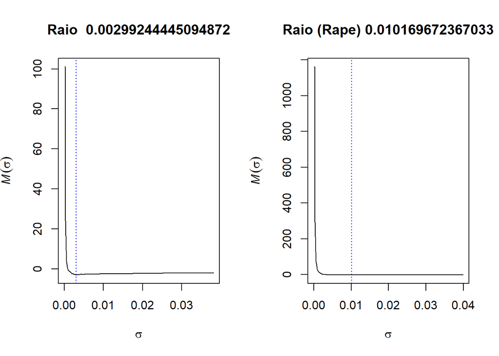

```r
#-------------------------------------------------------------------------------
#------------------------FUNÇÃO DE PRMEIRA ORDEM--------------------------------
#-------------------------------------------------------------------------------

par(mfrow=c(1,2))

#Funcao que estima o raio por meio de validacao cruzada
raio.est = bw.diggle(Houston_ppp)
plot(raio.est, main= paste("Raio ",raio.est, sep=" "))

#Funcao que estima o raio por meio de validacao cruzada
raio_Rape.est = bw.diggle(Houston_Rape_ppp)
plot(raio_Rape.est, main= paste("Raio (Rape)",raio_Rape.est, sep=" "))
```

```r
par(mfrow=c(1,1))
```

Como entendemos que o raio escolhido exerce grande influência no resultado da intensidade, nós estimamos o raio por validação cruzada obtendo o resultado 0.002992444. A seguir Plotaremos o mapa com o raio estimado e Kernel Gaussian, esse Estimador é um método de interpolação que mede a intensidade de ocorrências do processo em toda região de estudo. Assim criamos as primeiras impressões sobre o padrão dos pontos.

##### Plotando o mapa com o raio estimado e kernel Gaussian

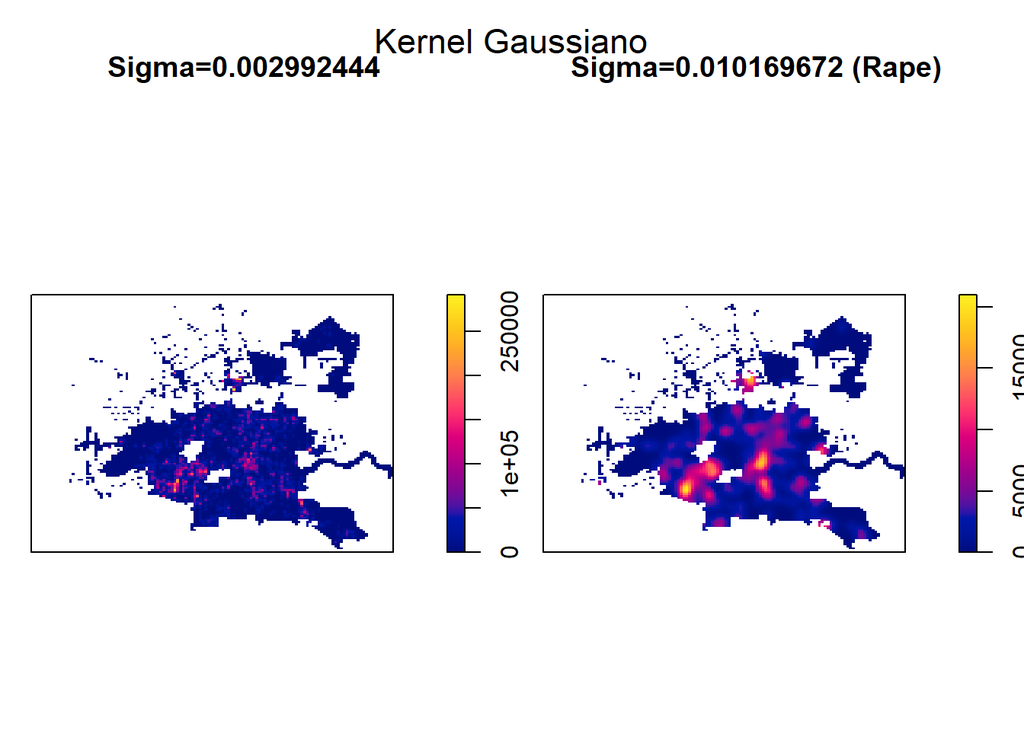

```r
par(mfrow=c(1,2))
par(mar=c(0.5,0.5,4.5,1))

plot(density.ppp(Houston_ppp, sigma=raio.est, kernel="gaussian"), main="Sigma=0.002992444 ", cex.main=0.002)
plot(density.ppp(Houston_Rape_ppp, sigma=raio_Rape.est, kernel="gaussian"), main="Sigma=0.010169672 (Rape) ",cex.main=0.010)

mtext("Kernel Gaussiano", outer=TRUE ,side = 3,line=-2, cex = 1.4)
```

```r
par(mfrow=c(1,1))
```

O mapa com raio ótimo nos permite ter a intuição de que há agrupamento em determinados pontos do mapa. Para confirmarmos ou não esse sentimento ainda teremos que realizar mais análizes.

#### Analisando efeitos de segunda ordem

Após observarmos os padrões dos pontos na Função de primeira ordem, denotaremos um processo pontual com função de intensidade de Segunda Ordem, onde analisaremos a distância do vizinho mais próximo

##### Teste de completa aleatoriedade espacial (CSR)

###### Método da quadratura

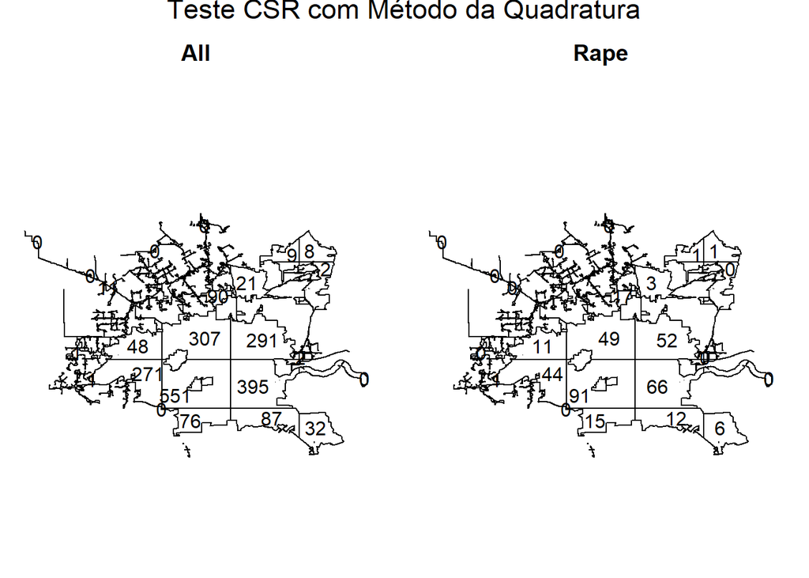

```r
#----------------------------------------------------------------------------------
#---------------------Testando completa aleatoriedade espacial(CSR)----------------
#----------------------------------------------------------------------------------

#Método da quadratura
cont = quadratcount(X = Houston_ppp, nx = 5, ny = 5)

cont_Rape = quadratcount(X = Houston_Rape_ppp, nx = 5, ny = 5)

##quadratcount - dividi uma janela em retangulos e conta o numero de pontos em cada
#um deles
#Argumentos:
#X - objeto do tipo ppp
#nx - numero de particoes no eixo x
#nx - numero de particoes no eixo y

#Visualizando as contagens em cada celula
#cont

#Plotando as contagens
par(mfrow=c(1,2))
par(mar=c(0.5,0.5,4.5,1))
plot(cont, main="All")
plot(cont_Rape, main="Rape")
mtext("Teste CSR com Método da Quadratura", outer=TRUE ,side = 3,line=-1, cex = 1.4)
```

```r
par(mfrow=c(1,1))
```

###### Método qui-quadrado

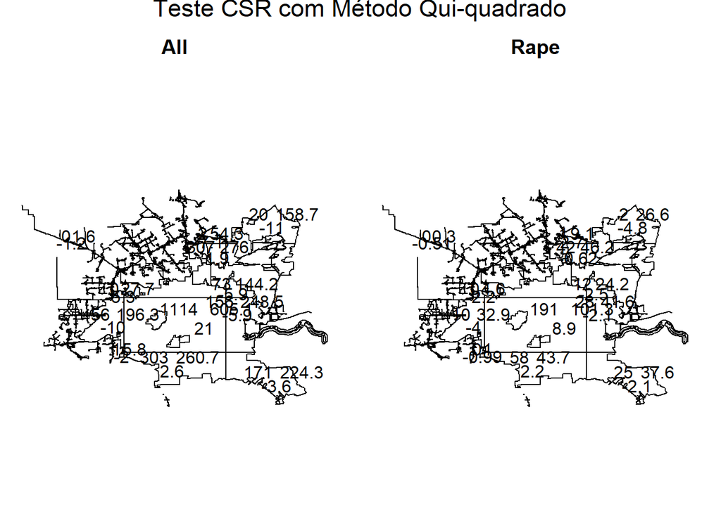

```r
##quadrat.test - realiza um teste de qui-quadrado para testar completa aleatoriedade
#espacial
teste = quadrat.test(X = Houston_ppp, nx = 3, ny = 4)

teste_Rape = quadrat.test(X = Houston_Rape_ppp, nx = 3, ny = 4)
#Argumentos:
#X - objeto do tipo ppp
#nx - numero de particoes no eixo x
#nx - numero de particoes no eixo y

#Visualizando o resultado do teste
#teste

#Plotando o teste
par(mfrow=c(1,2))
par(mar=c(0.5,0.5,4.5,1))
plot(teste, main="All")
plot(teste_Rape, main="Rape")
mtext("Teste CSR com Método Qui-quadrado", outer=TRUE ,side = 3,line=-1, cex = 1.4)
```

```r
par(mfrow=c(1,1))
```

###### Testes de hipoteses Clarkevans e Hospkel

```r
#------------------Testes de hipoteses Clarkevans e Hospkel-------------------------
clarkevans.test(Houston_ppp)
```

```
##
##  Clark-Evans test
##  No edge correction
##  Z-test
##
## data:  Houston_ppp
## R = 0.63085, p-value < 2.2e-16
## alternative hypothesis: two-sided
```

```r
hopskel.test(Houston_ppp, alternative="clustered")
```

```
##
##  Hopkins-Skellam test of CSR
##  using F distribution
##
## data:  Houston_ppp
## A = 0.048644, p-value < 2.2e-16
## alternative hypothesis: clustered (A < 1)
```

```r
clarkevans.test(Houston_Rape_ppp)
```

```
##
##  Clark-Evans test
##  No edge correction
##  Z-test
##
## data:  Houston_Rape_ppp
## R = 0.81568, p-value = 1.257e-11
## alternative hypothesis: two-sided
```

```r
hopskel.test(Houston_Rape_ppp, alternative="clustered")
```

```
##
##  Hopkins-Skellam test of CSR
##  using F distribution
##
## data:  Houston_Rape_ppp
## A = 0.087555, p-value < 2.2e-16
## alternative hypothesis: clustered (A < 1)
```

##### Funções K, G e F

Como rejeitamos a hipótese nula de completa aleatoriedade espacial, iremos utilizar outras alternativas da literatura

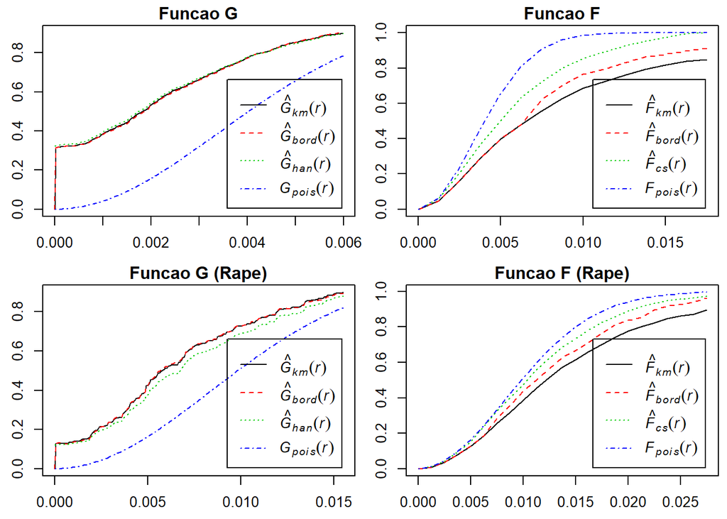

```r
#-------------------------------FUNÇÕES K,G e F-----------------------------------

#Estimando a funcao G
Houston.G = Gest(Houston_ppp)
#Estimando a funcao K (alto custo computacional)
#Houston.K = Kest(Houston_ppp)
#Estimando a funcao F
Houston.F = Fest(Houston_ppp)

#Estimando a funcao G
Houston_Rape.G = Gest(Houston_Rape_ppp)
#Estimando a funcao K (alto custo computacional)
#Houston_Rape.K = Kest(Houston_Rape_ppp)
#Estimando a funcao F
Houston_Rape.F = Fest(Houston_Rape_ppp)


#Plotando as funcoes G, K e F
par(mfrow = c(2,2))
par(mar=c(2.5,2.5,1.5,.5))

plot(Houston.G, main="Funcao G")
#plot(Houston.K, main="Funcao K")
plot(Houston.F, main="Funcao F")

plot(Houston_Rape.G, main="Funcao G (Rape)")
#plot(Houston_Rape.K, main="Funcao K (Rape)")
plot(Houston_Rape.F, main="Funcao F (Rape)")
```

- Na Função G a curva estimada dos dados esta oposta superiormente a curva de Poisson indicando agrupamento.
- Na Função F a curva estimada está abaixo da curva de Poisson, na qual também indica agrupameto

##### Envelopamento

```r
#------------------------------------Envelopamento----------------------------

#envelopado
Houston_envelop_G = envelope(Houston_ppp,fun = Gest, nsim=20)
```

```
## Generating 20 simulations of CSR  ...
## 1, 2, 3, 4, 5, 6, 7, 8, 9, 10, 11, 12, 13, 14, 15, 16, 17, 18, 19,  20.
##
## Done.
```

```r
#Houston_envelop_K = envelope(Houston_ppp,fun = Kest, nsim=20) #(alto custo computacional)
Houston_envelop_F = envelope(Houston_ppp,fun = Fest, nsim=20)
```

```
## Generating 20 simulations of CSR  ...
## 1, 2, 3, 4, 5, 6, 7, 8, 9, 10, 11, 12, 13, 14, 15, 16, 17, 18, 19,  20.
##
## Done.
```

```r
Houston_Rape_envelop_G = envelope(Houston_Rape_ppp,fun = Gest, nsim=20)
```

```
## Generating 20 simulations of CSR  ...
## 1, 2, 3, 4, 5, 6, 7, 8, 9, 10, 11, 12, 13, 14, 15, 16, 17, 18, 19,  20.
##
## Done.
```

```r
#Houston_Rape_envelop_K = envelope(Houston_Rape_ppp,fun = Kest, nsim=20) #(alto custo computacional)
Houston_Rape_envelop_F = envelope(Houston_Rape_ppp,fun = Fest, nsim=20)
```

```
## Generating 20 simulations of CSR  ...
## 1, 2, 3, 4, 5, 6, 7, 8, 9, 10, 11, 12, 13, 14, 15, 16, 17, 18, 19,  20.
##
## Done.
```

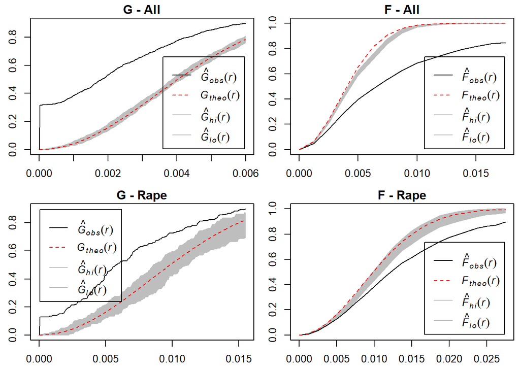

```r
par(mfrow = c(2,2))
par(mar=c(2.5,2.5,1.5,.5))

plot(Houston_envelop_G, main="G - All")
#A curva estimada está fora do envelope, indicando agrupamento
#plot(Houston_envelop_k, main="K - All")
plot(Houston_envelop_F, main="F - All")
#A curva estimada está fora do envelope, indicando agrupamento

plot(Houston_Rape_envelop_G, main="G - Rape")
#A curva estimada está fora do envelope, indicando agrupamento
#plot(Houston_Rape_envelop_k, main="K - Rape")
plot(Houston_Rape_envelop_F,main="F - Rape")
```

```r
#A curva estimada está fora do envelope, indicando agrupamento
```

- Nas funções G e F a curva estimada está fora do envelope, indicando agrupamento

#### Ajuste 1 - Ajustando o processo de Poisson homogeneo

- Para estimarmos a aleatoriedade dos pontos usaremos o modelo mais trivial, o Processo de Poisson homogêneo.

```r
#-------------------------------------------------------------------------------------#
# ------------------ Ajustando o processo de Poisson homogeneo----------------------#
#-------------------------------------------------------------------------------------#



#Ajustando o processo de Poisson homogeneo
ajuste1 = ppm(Q = Houston_ppp ~ 1)
ajuste1_Rape = ppm(Q = Houston_Rape_ppp ~ 1)
##ppm - Ajusta o processo de Poisson
#Argumentos:
#Q - Objeto ppp ~ 1 (ajusta o homogêneo)

#Visualizando o modelo ajustado
ajuste1
```

```
## Stationary Poisson process
## Intensity: 13613.07
##             Estimate       S.E.  CI95.lo  CI95.hi Ztest     Zval
## log(lambda) 9.518786 0.02130555 9.477028 9.560544   *** 446.7749
```

```r
ajuste1_Rape
```

```
## Stationary Poisson process
## Intensity: 2280.174
##             Estimate       S.E.  CI95.lo  CI95.hi Ztest    Zval
## log(lambda) 7.732007 0.05205792 7.629975 7.834039   *** 148.527
```

#### Ajuste 2 - Ajustando o processo de Poisson não-homogeneo

Plotando a função de intensidade ajustada em função das coordenadas x e y, e o erro padrão da função de intensidade ajustada pelo modelo

```r
#-------------------------------------------------------------------------------------#
# ------------------ Ajustando o processo de Poisson nao-homogeneo   -----------------#
#-------------------------------------------------------------------------------------#

#Ajustando um processo de Poisson nao-homogeneo que e log-linear nas coordenadas cartesianas
ajuste2 = ppm(Q = Houston_ppp ~ x + y)

#Visualizando o modelo ajustado
ajuste2
```

```
## Nonstationary Poisson process
##
## Log intensity:  ~x + y
##
## Fitted trend coefficients:
## (Intercept)           x           y
##  -24.815659   -1.105349   -2.388710
##
##               Estimate       S.E.    CI95.lo    CI95.hi Ztest       Zval
## (Intercept) -24.815659 13.2216638 -50.729644  1.0983254        -1.876894
## x            -1.105349  0.1291087  -1.358397 -0.8523003   ***  -8.561382
## y            -2.388710  0.1882264  -2.757627 -2.0197929   *** -12.690620
```

```r
ajuste2_Rape = ppm(Q = Houston_Rape_ppp ~ x + y)

#Visualizando o modelo ajustado
ajuste2_Rape
```

```
## Nonstationary Poisson process
##
## Log intensity:  ~x + y
##
## Fitted trend coefficients:
## (Intercept)           x           y
##  -25.354583   -1.137431   -2.533293
##
##               Estimate       S.E.    CI95.lo    CI95.hi Ztest       Zval
## (Intercept) -25.354583 32.4448680 -88.945356 38.2361901       -0.7814667
## x            -1.137431  0.3176451  -1.760004 -0.5148582   *** -3.5808237
## y            -2.533293  0.4657488  -3.446143 -1.6204417   *** -5.4391825
```

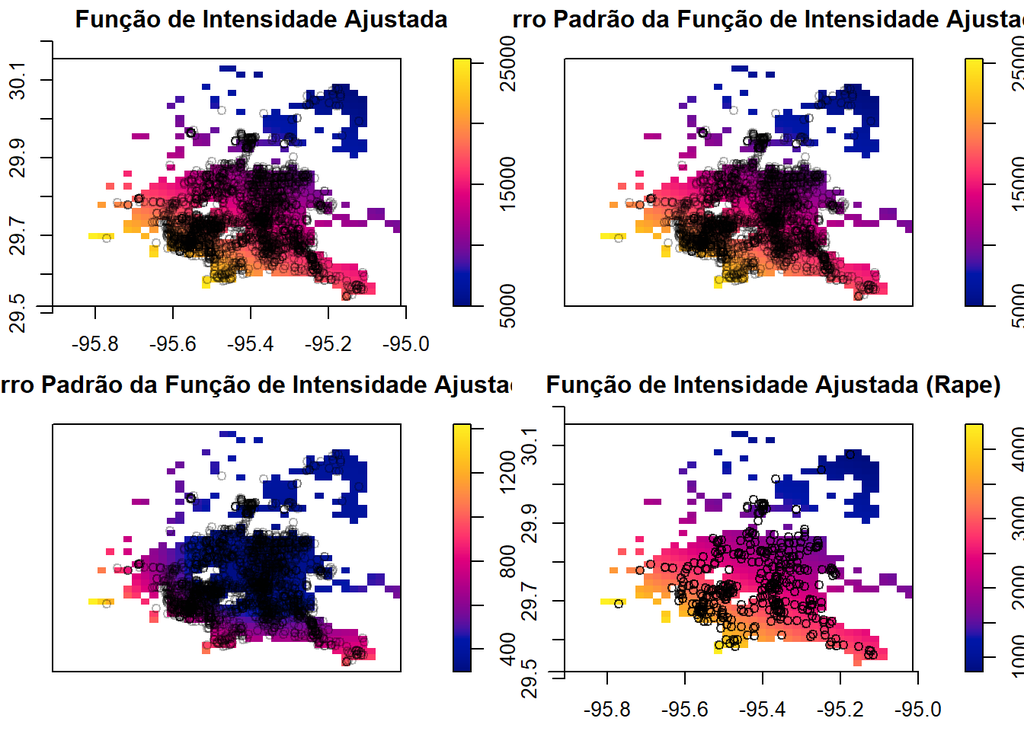

```r
#Plotando a funcao de intensidade ajustada em funcao das coordenadas x e y
par(mfrow=c(2,2))
par(mar=c(1.5,1.5,1.5,1))

plot(ajuste2, how = "image", se = FALSE, pause = FALSE, axes = TRUE, main="Função de Intensidade Ajustada")
#Plotando o erro padrao da funcao de intensidade ajustada pelo modelo
plot(ajuste2, how = "image", se = TRUE, pause = FALSE, main="Erro Padrão da Função de Intensidade Ajustada")

plot(ajuste2_Rape, how = "image", se = FALSE, pause = FALSE, axes = TRUE, main="Função de Intensidade Ajustada (Rape)")
```

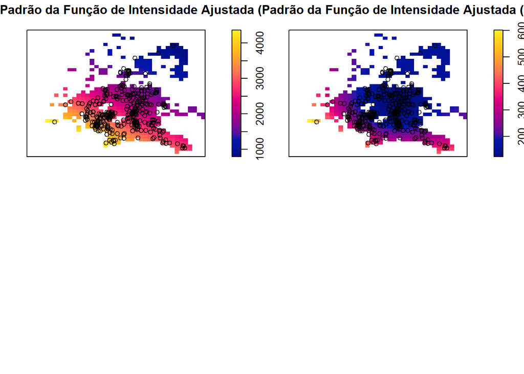

```r
#Plotando o erro padrao da funcao de intensidade ajustada pelo modelo
plot(ajuste2_Rape, how = "image", se = TRUE, pause = FALSE, main="Erro Padrão da Função de Intensidade Ajustada (Rape)")
```

##### Calculando o efeito de uma unica variavel no modelo

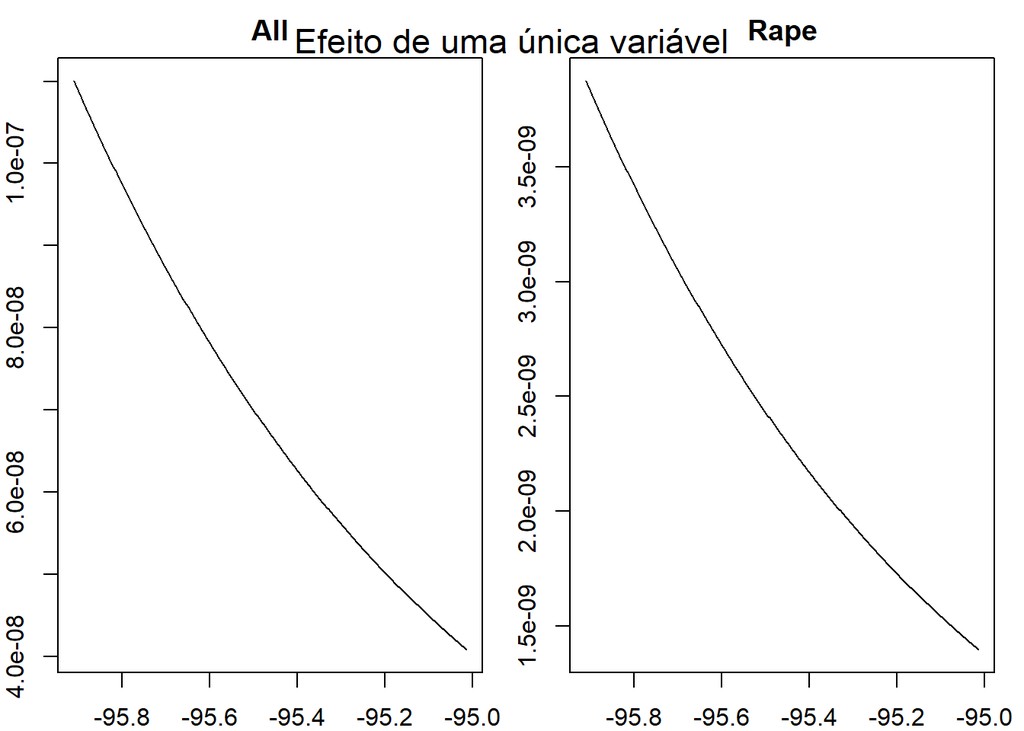

```r
#Calculando o efeito de uma unica variavel no modelo
efeito.1vari = effectfun(model = ajuste2, covname = "x", y = 40.7)
efeito_Rape.1vari = effectfun(model = ajuste2_Rape, covname = "x", y = 40.7)

#Plotando o efeito de uma unica covariavel no modelo
par(mfrow=c(1,2))
par(mar=c(2,2,2,1))

plot(efeito.1vari , main = "All")
plot(efeito_Rape.1vari , main = "Rape")

mtext("Efeito de uma única variável", outer=TRUE ,side = 3,line=-2, cex = 1.4)
```

```r
par(mfrow=c(1,1))

##effectfun - realiza um teste de qui-quadrado para testar completa aleatoriedade espacial
#Argumentos:
#model - modelo ajustado
#covname - nome da variavel que quer avaliar o efeito
#y - foi preciso colocar um valor de y, pois estamos desejando ver o efeito em x
```